# Exploring Hass Avocado Market Trends

**Will Silver Wagman**

Final Data Science Project Tutorial

CMPS-3160-01 - Introduction to Data Science - Professor Culotta

[Link to GitHub.io site](https://will5206.github.io/)

## I. Introduction and Project Description

In the ever-evolving landscape of retail analytics, certain commodities stand out due to their unique market dynamics. The avocado, a fruit that has surged in popularity across various consumer demographics, exemplifies such a commodity. Its rise in the global market is marked by notable characteristics: price volatility, distinct seasonality, and an increasing demand influenced by health and dietary trends. This project aims to delve into the intricacies of the avocado market, focusing on Hass avocados, a variety notable for its widespread consumption.

The primary dataset for this project is sourced from Kaggle and originally compiled by the Hass Avocado Board. It encompasses weekly retail scan data from 2015 to 2018, capturing essential aspects of the market such as average price, total sales volume, packaging types, and geographical sales distribution. The dataset's 13 variables provide a comprehensive view of Hass avocado sales across various regions.

In addition to the Hass Avocado dataset, this project integrates a second dataset: U.S. cities' weather data. This dataset offers daily weather metrics for several cities, including temperature, precipitation, and wind speed. By merging these datasets, the project seeks to uncover correlations between weather conditions and avocado market trends.

[Link to Hass Avocado dataset](https://www.kaggle.com/datasets/neuromusic/avocado-prices/data)

[Link to Hass Avocado Board Website](https://hassavocadoboard.com/)

[Link to The Weather Dataset](https://www.kaggle.com/datasets/guillemservera/global-daily-climate-data)

### I.a. Project Goals

The project's objective is to conduct an in-depth analysis of the avocado market, primarily focusing on the following aspects:

1. Price and Sales Trends:
- How do avocado prices fluctuate over time?
- Are there identifiable seasonal trends in avocado sales?
- Which cities exhibit the highest and lowest sales volumes?
1. Weather Impact Analysis:
- How do weather conditions correlate with avocado prices and sales volumes?
- Can specific weather patterns be linked to fluctuations in the avocado market?
1. Regional Market Dynamics:
- Is there a relationship between avocado prices and sales volumes across different regions?
1. Machine Learning Applications:
- Developing a predictive model for future avocado prices based on historical data and weather conditions.
- Exploring the feasibility of clustering techniques to categorize regions with similar avocado buying behaviors.
1. Statistical Analysis:
- Conducting hypothesis testing to ascertain if there are significant differences in avocado prices across different years.
- Analyzing correlations between various numerical variables in the dataset.

### I.b. Collaboration Plan

As the sole architect of this project, I intend to employ a sophisticated set of tools to ensure seamless workflow and optimum productivity. For task management and organizational structuring, I will utilize Obsidian—a robust knowledge base that works on top of a local folder of plain text Markdown files. This tool will serve as the backbone for my project planning, allowing me to create interlinked notes that outline tasks, deadlines, and key milestones.

In terms of code repository and version control, GitHub will be my platform of choice. Its robust features will enable me to keep track of all changes, thereby maintaining a clean and well-documented codebase. This is particularly crucial for a project that spans multiple weeks and involves various components, from data extraction and cleaning to analysis and visualization.

While Google Colab will be my primary environment for data analysis due to its easy-to-share notebooks and powerful cloud-based computing, I will also make use of Visual Studio Code (VSCode) for exploratory analyses. The rationale behind this is to maintain the integrity of my Colab notebooks by preventing inadvertent changes to key components. VSCode offers an excellent platform for quick, ad-hoc analysis and prototyping, providing me the flexibility to experiment without affecting the main codebase.

To ensure the project stays on course and aligns with its objectives, I will establish weekly checkpoints. These will serve as dedicated time slots for a comprehensive review of what has been accomplished and what lies ahead. During these checkpoints, I will assess the project's current status, revisiting and refining my initial plans as needed. This will include making any necessary additions to the project scope or adjustments to the existing methodologies, thereby ensuring that the project not only stays on track but also adapts to any new insights or challenges that may arise.

## II. Extraction, Transform, and Load (ETL)

For the first step of ETL I am going to load the data into a Pandas DataFrame and look at the first few rows to understand its structure.

```python
# First I am going to mount my Google Drive so that I can access my Hass Avocado dataset .csv file.

from google.colab import drive
drive.mount('/content/drive')
```

```python
import pandas as pd
import matplotlib.pyplot as plt
import numpy as np


# Loading the dataset
avocado_dataset_path = '/content/drive/MyDrive/Colab Notebooks/avocado.csv'
avocado_df = pd.read_csv(avocado_dataset_path)

# Show the first few rows of the dataset to understand its structure
avocado_df.head()
```

|  | Unnamed: 0 | Date | AveragePrice | Total Volume | 4046 | 4225 | 4770 | Total Bags | Small Bags | Large Bags | XLarge Bags | type | year | region |
| --- | --- | --- | --- | --- | --- | --- | --- | --- | --- | --- | --- | --- | --- | --- |
| 0 | 0 | 2015-12-27 | 1.33 | 64236.62 | 1036.74 | 54454.85 | 48.16 | 8696.87 | 8603.62 | 93.25 | 0.0 | conventional | 2015 | Albany |
| 1 | 1 | 2015-12-20 | 1.35 | 54876.98 | 674.28 | 44638.81 | 58.33 | 9505.56 | 9408.07 | 97.49 | 0.0 | conventional | 2015 | Albany |
| 2 | 2 | 2015-12-13 | 0.93 | 118220.22 | 794.70 | 109149.67 | 130.50 | 8145.35 | 8042.21 | 103.14 | 0.0 | conventional | 2015 | Albany |
| 3 | 3 | 2015-12-06 | 1.08 | 78992.15 | 1132.00 | 71976.41 | 72.58 | 5811.16 | 5677.40 | 133.76 | 0.0 | conventional | 2015 | Albany |
| 4 | 4 | 2015-11-29 | 1.28 | 51039.60 | 941.48 | 43838.39 | 75.78 | 6183.95 | 5986.26 | 197.69 | 0.0 | conventional | 2015 | Albany |

After loading the dataset, we can see that there are 13 variables:

1. `Date`
2. `AveragePrice`
3. `Total Volume`
4. `4046`
5. `4225`
6. `4770`
7. `Total Bags`
8. `Small Bags`
9. `Large Bags`
10. `XLarge Bags`
11. `type`
12. `year`
13. `region`

Here is a key for some relevant columns in the dataset:

`Date` - The date of the observation

`AveragePrice` - the average price of a single avocado

`type` - conventional or organic

`year` - the year

`Region` - the city or region of the observation

`Total Volume` - Total number of avocados sold

`4046` - Total number of avocados with PLU 4046 sold

`4225` - Total number of avocados with PLU 4225 sold

`4770` - Total number of avocados with PLU 4770 sold

Let's start by looking at the shape of the data and the data types of each column. I will also check for missing values.

After that, I will proceed to do some light exploratory data analysis (EDA) to find some interesting statistics as well as generate our first graph. This will give me more insights into the data and help me frame my questions better.

```python
# Checking the shape and data types of the dataset

shape = avocado_df.shape
data_types = avocado_df.dtypes

# Check for missing values
missing_values = avocado_df.isnull().sum()

shape, data_types, missing_values
```

```
((18249, 14),
 Unnamed: 0        int64
 Date             object
 AveragePrice    float64
 Total Volume    float64
 4046            float64
 4225            float64
 4770            float64
 Total Bags      float64
 Small Bags      float64
 Large Bags      float64
 XLarge Bags     float64
 type             object
 year              int64
 region           object
 dtype: object,
 Unnamed: 0      0
 Date            0
 AveragePrice    0
 Total Volume    0
 4046            0
 4225            0
 4770            0
 Total Bags      0
 Small Bags      0
 Large Bags      0
 XLarge Bags     0
 type            0
 year            0
 region          0
 dtype: int64)
```

Here are some observations I made from the ETL:

- The dataset has 18,249 rows and 14 columns
- Data types vary from integers (int64) to floats (float64) and objects (object), which usually indicate string data.
- There are no missing values in the dataset, which is great as it saves me from having to perform imputation.

Next Steps for ETL:

1. The column Date is of object type, so we may need to convert it into a datetime format for easier time-series analysis.
2. The column `Unnamed: 0` seems like it is an index column. I may consider dropping it after confirming its relevance.

Updates:

1. In the following cell I convert the 'Date' column to datetime format and sort the rows by date.
2. In the following cell I have removed the `Unnamed: 0` column as I have confirmed that it is indeed an index column.
3. Note: I am leaving the original index row numbers as is (even though I have sorted the rows by date) as I feel like I may want to preserve these for future manipulation.

Light Exploratory Data Analysis (EDA):

Let's proceed with some light EDA by calculating 3 interesting summary statistics and generating a few graphs. The goal here is to answer the 3 basic EDA questions that I outlined above.

```python
# Converting the 'Date' column to datetime format and sort by Date
avocado_df['Date'] = pd.to_datetime(avocado_df['Date'])
avocado_df.sort_values('Date', inplace=True)
avocado_df = avocado_df.drop(columns=['Unnamed: 0'])

# Calculating the standard deviation of the AveragePrice over time
price_volatility = avocado_df.groupby('Date')['AveragePrice'].std()

# Aggregating the Total Volume sold by month
avocado_df['Month'] = avocado_df['Date'].dt.month
seasonal_sales_trends = avocado_df.groupby('Month')['Total Volume'].mean()

# Regions with the highest and lowest total sales volume
region_sales = avocado_df.groupby('region')['Total Volume'].sum()

# Filtering out the aggregate categories like 'TotalUS' to focus only on city names for regional sales
city_sales = region_sales.drop(['TotalUS', 'West', 'Midsouth', 'Northeast', 'SouthCentral', 'Southeast', 'GreatLakes', 'Plains'])

# Regions (city names) with the highest and lowest total sales volume
highest_sales_city = city_sales.idxmax()
lowest_sales_city = city_sales.idxmin()
highest_sales_city_value = city_sales.max()
lowest_sales_city_value = city_sales.min()
```

```python
avocado_df.head()
```

|  | Date | AveragePrice | Total Volume | 4046 | 4225 | 4770 | Total Bags | Small Bags | Large Bags | XLarge Bags | type | year | region | Month |
| --- | --- | --- | --- | --- | --- | --- | --- | --- | --- | --- | --- | --- | --- | --- |
| 11569 | 2015-01-04 | 1.75 | 27365.89 | 9307.34 | 3844.81 | 615.28 | 13598.46 | 13061.10 | 537.36 | 0.0 | organic | 2015 | Southeast | 1 |
| 9593 | 2015-01-04 | 1.49 | 17723.17 | 1189.35 | 15628.27 | 0.00 | 905.55 | 905.55 | 0.00 | 0.0 | organic | 2015 | Chicago | 1 |
| 10009 | 2015-01-04 | 1.68 | 2896.72 | 161.68 | 206.96 | 0.00 | 2528.08 | 2528.08 | 0.00 | 0.0 | organic | 2015 | HarrisburgScranton | 1 |
| 1819 | 2015-01-04 | 1.52 | 54956.80 | 3013.04 | 35456.88 | 1561.70 | 14925.18 | 11264.80 | 3660.38 | 0.0 | conventional | 2015 | Pittsburgh | 1 |
| 9333 | 2015-01-04 | 1.64 | 1505.12 | 1.27 | 1129.50 | 0.00 | 374.35 | 186.67 | 187.68 | 0.0 | organic | 2015 | Boise | 1 |

```python
# Here I am making sure that data types have been corrected (such as removing the 'Unnamed: 0' column and changing 'Date' from object to datetime)
avocado_df.dtypes
```

```
Date            datetime64[ns]
AveragePrice           float64
Total Volume           float64
4046                   float64
4225                   float64
4770                   float64
Total Bags             float64
Small Bags             float64
Large Bags             float64
XLarge Bags            float64
type                    object
year                     int64
region                  object
Month                    int64
dtype: object
```

Now, before creating and looking at EDA graphs, let's take a look at some summary data from the variables I just created.

```python
price_volatility.describe(), seasonal_sales_trends.describe(), (highest_sales_city), (highest_sales_city_value), (lowest_sales_city), (lowest_sales_city_value)
```

```
(count    169.000000
 mean       0.372216
 std        0.045109
 min        0.257353
 25%        0.343776
 50%        0.368617
 75%        0.403340
 max        0.482861
 Name: AveragePrice, dtype: float64,
 count    1.200000e+01
 mean     8.449857e+05
 std      1.085356e+05
 min      6.796073e+05
 25%      7.693026e+05
 50%      8.696209e+05
 75%      9.100090e+05
 max      1.018825e+06
 Name: Total Volume, dtype: float64,
 'California',
 1028981653.17,
 'Syracuse',
 10942667.68)
```

Now I'm going to proceed to create two graphs. One will show price volatility over time and the other will show seasonal sales trends by month.

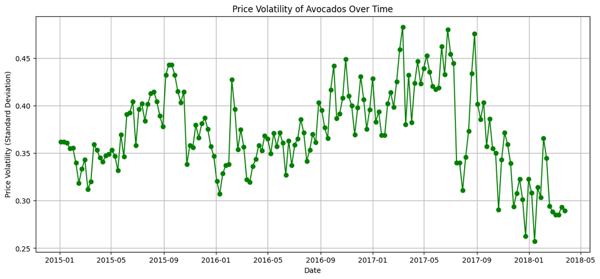

```python
# 1. Price Volatility Over Time
plt.figure(figsize=(14, 6))
plt.plot(price_volatility.index, price_volatility.values, marker='o', linestyle='-', color='green')
plt.title('Price Volatility of Avocados Over Time')
plt.xlabel('Date')
plt.ylabel('Price Volatility (Standard Deviation)')
plt.grid(True)
plt.show()
```

Graphical Insights: Price Volatility Over Time

The graph visually illustrates the fluctuations in avocado prices over time. It allows us to see periods when prices were highly volatile, which could be indicative of supply issues or high demand.

Now I will create the graph showing seasonal sales trends.

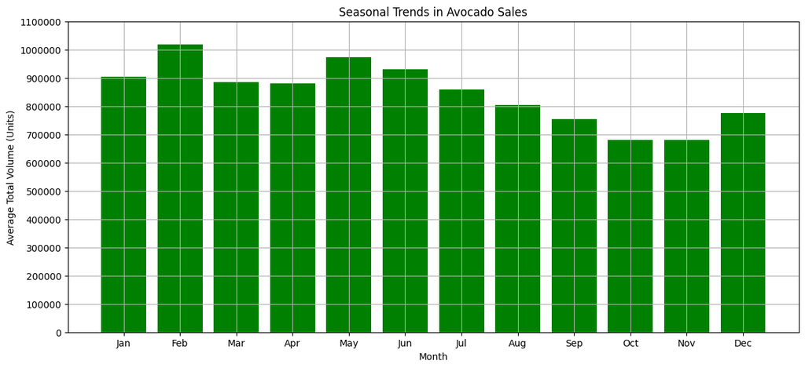

```python
# 2. Seasonal Sales Trends by Month
plt.figure(figsize=(14, 6))
plt.bar(seasonal_sales_trends.index, seasonal_sales_trends.values, color='green')
plt.title('Seasonal Trends in Avocado Sales')
plt.xlabel('Month')
plt.ylabel('Average Total Volume (Units)')
plt.xticks(np.arange(1, 13), ['Jan', 'Feb', 'Mar', 'Apr', 'May', 'Jun', 'Jul', 'Aug', 'Sep', 'Oct', 'Nov', 'Dec'])

# Define the yticks to start from zero and go a bit higher than the maximum value in the data
max_value = seasonal_sales_trends.max()
yticks = np.arange(0, int(max_value) + 100000, step=100000)
plt.yticks(yticks, [str(int(y)) for y in yticks])

plt.grid(True)
plt.show()
```

Graphical Insights: Seasonal Sales Trends by Month

Now I will create a graph showing the city-wise sales volumes.

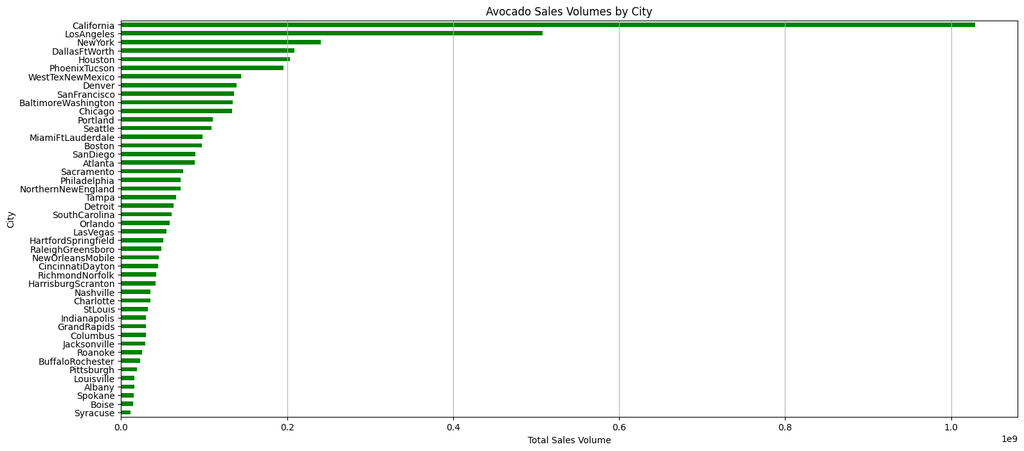

```python
# Plotting city-wise sales volumes
plt.figure(figsize=(18, 8))
city_sales.sort_values().plot(kind='barh', color='green')
plt.title('Avocado Sales Volumes by City')
plt.xlabel('Total Sales Volume')
plt.ylabel('City')
plt.grid(axis='x')
plt.show()
```

Graphical Insight: Avocado Sales Volumes by City

The horizontal bar graph illustrates the total sales volumes of avocados for various cities. As you can see:

- 'California' leads in sales volume by a significant margin.
- 'Syracuse' has the lowest sales volume among the cities listed.

This visualization provides a clear picture of the disparity in sales volumes across different cities.

### Light EDA Summary Statistics Insights

1. Avocado Price Fluctuations Statistic: The standard deviation of the average price over time ranges from approximately 0.257 to 0.482 (not rounded).
   - Justification: The standard deviation helps us understand the volatility in avocado prices. A higher standard deviation would mean higher fluctuations in prices. This statistic is directly related to the question about how avocado prices fluctuate over time.
2. Seasonal Trends in Avocado Sales Statistic: The average total volume of avocado sales varies significantly by month, ranging from approximately 679,607 units to 1,018,825 units.
   - Justification: This statistic sheds light on the seasonal trends in avocado sales, showing which months are peak seasons for avocado sales. This directly relates to the question about identifying seasonal trends.
3. City Sales Volume Statistic: Focusing only on city names, the region with the highest total sales volume is 'California' with approximately 1.03 billion units sold. The region with the lowest total sales volume is 'Syracuse' with approximately 10.9 million units sold.
   - Justification: Understanding sales volumes at the city level can offer more granular insights for localized marketing strategies or distribution plans.

# Milestone 2

Now I am going to integrate a second dataset: U.S. cities' weather data. This dataset offers daily weather metrics for several cities, including temperature, precipitation, and wind speed. By merging these datasets, the I seek to uncover correlations between weather conditions and avocado market trends.

First I am going to outline what I am going to do:

1. Additional ETL: Load and examine the new dataset (uscitiesweather.csv). Identify how it can be integrated with the avocado sales dataset. Perform necessary transformations to ensure the datasets are tidy and compatible for analysis.
2. Expanded EDA: Generate at least 5 graphs and summary statistics/tables, including cross-tabulations, groups, measures of central tendency, etc.
3. Model Questions: Outline at least two model ideas, identifying independent and dependent variables and the test/prediction methodology.

Now, I am going to start by loading the new dataset (uscitiesweather.csv) and conduct an initial examination to understand its structure and content.

```python
# Loading the new dataset "uscitiesweather.csv"
weather_dataset_path = '/content/drive/MyDrive/Colab Notebooks/uscitiesweather.csv'
weather_df = pd.read_csv(weather_dataset_path)

# Show the first few rows to understand its structure
weather_df.head()
```

|  | Unnamed: 0 | station_id | city_name | date | season | avg_temp_c | min_temp_c | max_temp_c | precipitation_mm | snow_depth_mm | avg_wind_dir_deg | avg_wind_speed_kmh | peak_wind_gust_kmh | avg_sea_level_pres_hpa | sunshine_total_min |
| --- | --- | --- | --- | --- | --- | --- | --- | --- | --- | --- | --- | --- | --- | --- | --- |
| 0 | 0 | 60419 | constantine | 1943-03-01 | Spring | 8.9 | 2.4 | 15.7 | NaN | NaN | 12.0 | 6.2 | NaN | 1030.9 | NaN |
| 1 | 1 | 60419 | constantine | 1943-03-02 | Spring | 7.4 | -1.5 | 16.3 | NaN | NaN | 0.0 | 4.5 | NaN | 1030.4 | NaN |
| 2 | 2 | 60419 | constantine | 1943-03-03 | Spring | 8.7 | -0.9 | 18.0 | NaN | NaN | 285.0 | 6.5 | NaN | 1024.7 | NaN |
| 3 | 3 | 60419 | constantine | 1943-03-04 | Spring | 9.3 | 2.4 | 16.3 | NaN | NaN | 25.0 | 2.9 | NaN | 1019.9 | NaN |
| 4 | 4 | 60419 | constantine | 1943-03-05 | Spring | 11.1 | 5.8 | 16.3 | NaN | NaN | 234.0 | 8.3 | NaN | 1022.3 | NaN |

The uscitiesweather.csv dataset contains weather data for various cities, with the following columns:

Unnamed: 0: Appears to be an index column. station_id: Identifier for the weather station. city_name: Name of the city. date: Date of the observation. season: Season at the time of observation. avg_temp_c: Average temperature in Celsius. min_temp_c: Minimum temperature in Celsius. max_temp_c: Maximum temperature in Celsius. precipitation_mm: Precipitation in millimeters. snow_depth_mm: Snow depth in millimeters. avg_wind_dir_deg: Average wind direction in degrees. avg_wind_speed_kmh: Average wind speed in kilometers per hour. peak_wind_gust_kmh: Peak wind gust in kilometers per hour. avg_sea_level_pres_hpa: Average sea level pressure in hectopascals. sunshine_total_min: Total minutes of sunshine.

After examining the structure of the uscitiesweather.csv file, here are my bbservations and planned next-steps for ETL:

1. Data Cleaning:
- The Unnamed: 0 column seems redundant and can likely be dropped. Converting the date column to a datetime format would facilitate time-based analysis.
- Checking for missing values is important, especially since there are NaNs visible in the preview.
1. Data Integration:
- This dataset could be integrated with the avocado dataset by matching city_name with region and date with year (and possibly month). This would allow for analysis of how weather conditions affect avocado sales and prices.
1. Data Validation:
- Ensuring that the cities in the weather dataset match or overlap with the regions in the avocado dataset is crucial for meaningful integration and analysis.

```python
# Proceeding with the ETL steps for the uscitiesweather dataset

# Step 1: Data Cleaning
# Dropping the 'Unnamed: 0' column
uscitiesweather_df_cleaned = weather_df.drop(columns=['Unnamed: 0'])

# Converting 'date' column to datetime format
uscitiesweather_df_cleaned['date'] = pd.to_datetime(uscitiesweather_df_cleaned['date'])

# Step 2: Checking for missing values
missing_values = uscitiesweather_df_cleaned.isnull().sum()

# Displaying the cleaned dataframe and missing values information
uscitiesweather_df_cleaned.head(), missing_values
```

```
(  station_id    city_name       date  season  avg_temp_c  min_temp_c  \
 0      60419  constantine 1943-03-01  Spring         8.9         2.4
 1      60419  constantine 1943-03-02  Spring         7.4        -1.5
 2      60419  constantine 1943-03-03  Spring         8.7        -0.9
 3      60419  constantine 1943-03-04  Spring         9.3         2.4
 4      60419  constantine 1943-03-05  Spring        11.1         5.8

    max_temp_c  precipitation_mm  snow_depth_mm  avg_wind_dir_deg  \
 0        15.7               NaN            NaN              12.0
 1        16.3               NaN            NaN               0.0
 2        18.0               NaN            NaN             285.0
 3        16.3               NaN            NaN              25.0
 4        16.3               NaN            NaN             234.0

    avg_wind_speed_kmh  peak_wind_gust_kmh  avg_sea_level_pres_hpa  \
 0                 6.2                 NaN                  1030.9
 1                 4.5                 NaN                  1030.4
 2                 6.5                 NaN                  1024.7
 3                 2.9                 NaN                  1019.9
 4                 8.3                 NaN                  1022.3

    sunshine_total_min
 0                 NaN
 1                 NaN
 2                 NaN
 3                 NaN
 4                 NaN  ,
 station_id                      0
 city_name                       0
 date                            0
 season                          0
 avg_temp_c                1391577
 min_temp_c                 263498
 max_temp_c                 292427
 precipitation_mm           621014
 snow_depth_mm             2313805
 avg_wind_dir_deg          3159150
 avg_wind_speed_kmh        2442209
 peak_wind_gust_kmh        3468530
 avg_sea_level_pres_hpa    2650556
 sunshine_total_min        3387911
 dtype: int64)
```

Now the uscitiesweather dataset has been cleaned and the date column has been converted to the datetime format. Here are some insights and next steps based on the missing values:

Missing Values Overview:

Next Steps for ETL:

1. Handling Missing Data:
- Investigate patterns of missing data. Are there specific time periods or cities with more missing values? I am going to have to consider imputation methods or exclusion of certain variables with excessive missing data.
1. Data Integration:
- To integrate this weather dataset with the avocado dataset, aligning city names and dates will be necessary. This includes mapping city names to regions (if they differ) and aggregating weather data to a weekly level to match the avocado dataset's temporal granularity.
- Given the time range of the avocado dataset (2015-2018), it might be prudent to filter the weather data to this period for relevant analysis.
1. Exploratory Data Analysis (EDA):
- Initial EDA on weather variables could reveal patterns or trends useful for this project, such as seasonal variations in weather parameters.

```python
# Proceeding with the next steps for ETL and initial EDA

# Step 1: Handling Missing Data
# Here, I am nvestigating patterns of missing data, focusing on recent years (2015 onwards) as per the avocado dataset
uscitiesweather_recent = uscitiesweather_df_cleaned[uscitiesweather_df_cleaned['date'] >= '2015-01-01']

# Checking missing values for the recent years.
missing_values_recent = uscitiesweather_recent.isnull().sum()

# Step 2: Data Integration Preparation
# Filtering data to match the avocado dataset time period (2015-2018).
uscitiesweather_filtered = uscitiesweather_recent[uscitiesweather_recent['date'] <= '2018-12-31']

# Step 3: Initial EDA
# Basic descriptive statistics for key weather variables
weather_eda = uscitiesweather_filtered[['avg_temp_c', 'min_temp_c', 'max_temp_c', 'precipitation_mm']].describe()


missing_values_recent, uscitiesweather_filtered.head(), weather_eda
```

[output not shown]

ETL and Initial EDA Summary for uscitiesweather Dataset:

Missing Values in Recent Years (2015 onwards):

- avg_temp_c: 20,626 missing values.
- min_temp_c: 14,753 missing values.
- max_temp_c: 19,016 missing values.
- precipitation_mm: 69,777 missing values.
- snow_depth_mm, avg_wind_dir_deg, avg_wind_speed_kmh, peak_wind_gust_kmh, avg_sea_level_pres_hpa, sunshine_total_min: Significant number of missing values.

Data Integration Preparation:

- I have filtered the dataset to match the avocado dataset date range (2015-2018).
- The next step would involve aligning city names and dates with the avocado dataset.

Initial EDA (Descriptive Statistics for 2015-2018):

- Average Temperature (avg_temp_c):
  - Mean: 15.15°C, Min: -34.3°C, Max: 41.7°C.
- Minimum Temperature (min_temp_c):
  - Mean: 9.96°C, Min: -38.7°C, Max: 37.0°C.
- Maximum Temperature (max_temp_c):
  - Mean: 19.95°C, Min: -30.6°C, Max: 48.3°C.
- Precipitation (precipitation_mm):
  - Mean: 2.69 mm, Max: 496.1 mm.

Next Steps:

1. Data Integration:
- Mapping city names in the weather dataset to regions in the avocado dataset.
- Aggregating weather data to a weekly level for integration with the avocado dataset's temporal granularity.
1. Advanced EDA:
- Exploring correlations between weather conditions and avocado sales/prices.
- Investigating any seasonal or geographical patterns in weather data that correlate with avocado market trends.

City to Region Mapping for Data Integration: Given the unique city names from the weather dataset and the unique region names from the avocado dataset, a manual mapping was necessary to do. Here's an overview:

Unique Cities from Weather Dataset:

- Includes a variety of international cities (e.g., 'constantine', 'la plata') and U.S. cities (e.g., 'albany', 'atlanta').
- Some U.S. cities match directly with regions in the avocado dataset (e.g., 'Albany', 'Atlanta').

Unique Regions from Avocado Dataset:

- Mostly U.S. cities and regions (e.g., 'Albany', 'Atlanta', 'California').
- Some regions are broader geographical areas (e.g., 'Northeast', 'SouthCentral').

Here is the mapping strategy that I am going to pursue:

1. Direct Matches: Map cities in the weather dataset directly to regions in the avocado dataset where possible.
2. Broader Regions: For cities not directly matching, I'm going to map to broader geographical regions if it's appropriate.
3. Exclusions: Cities without a reasonable match in the avocado dataset might need to be excluded from the analysis.

Next Steps for Data Integration:

1. Create a mapping dictionary or function based on the strategy above.
2. Apply this mapping to the weather dataset to align it with the avocado dataset's regions.
3. Aggregate the weather data to a weekly level, matching the temporal granularity of the avocado dataset.

```python
# Loading the avocado dataset for integration with the weather dataset
avocado_dataset_path = '/content/drive/MyDrive/Colab Notebooks/avocado.csv'
avocado_df2 = pd.read_csv(avocado_dataset_path)

# Converting the 'Date' column to datetime format in the avocado dataset
avocado_df2['Date'] = pd.to_datetime(avocado_df2['Date'])

# Dropping irrelevant columns and checking the first few rows
avocado_df2 = avocado_df2.drop(columns=['Unnamed: 0'])
avocado_df2.head()
```

|  | Date | AveragePrice | Total Volume | 4046 | 4225 | 4770 | Total Bags | Small Bags | Large Bags | XLarge Bags | type | year | region |
| --- | --- | --- | --- | --- | --- | --- | --- | --- | --- | --- | --- | --- | --- |
| 0 | 2015-12-27 | 1.33 | 64236.62 | 1036.74 | 54454.85 | 48.16 | 8696.87 | 8603.62 | 93.25 | 0.0 | conventional | 2015 | Albany |
| 1 | 2015-12-20 | 1.35 | 54876.98 | 674.28 | 44638.81 | 58.33 | 9505.56 | 9408.07 | 97.49 | 0.0 | conventional | 2015 | Albany |
| 2 | 2015-12-13 | 0.93 | 118220.22 | 794.70 | 109149.67 | 130.50 | 8145.35 | 8042.21 | 103.14 | 0.0 | conventional | 2015 | Albany |
| 3 | 2015-12-06 | 1.08 | 78992.15 | 1132.00 | 71976.41 | 72.58 | 5811.16 | 5677.40 | 133.76 | 0.0 | conventional | 2015 | Albany |
| 4 | 2015-11-29 | 1.28 | 51039.60 | 941.48 | 43838.39 | 75.78 | 6183.95 | 5986.26 | 197.69 | 0.0 | conventional | 2015 | Albany |

```python
# Creating a mapping dictionary for cities in the weather dataset to regions in the avocado dataset.
# Note: This is not a fully comprehensive mapping and does not cover all cities since I would have to
# map out roughly 20,000 cities by hand for it to be fully comprehensive. However, I tried to choose cities
# that are spread out all around the United States so that I can continue with my analyses without the bias of
# mapping cities from, say, just one section of the United States.

# Mappings based on city name similarities and geographical relevance
city_to_region_map = {
    'albany': 'Albany',
    'atlanta': 'Atlanta',
    'boise': 'Boise',
    'boston': 'Boston',
    'denver': 'Denver',
    'detroit': 'Detroit',
    'houston': 'Houston',
    'los angeles': 'LosAngeles',
    'miami': 'MiamiFtLauderdale',
    'new york': 'NewYork',
    'philadelphia': 'Philadelphia',
    'phoenix': 'PhoenixTucson',
    'san francisco': 'SanFrancisco',
    'seattle': 'Seattle',
    'washington': 'BaltimoreWashington',
    'baltimore': 'BaltimoreWashington',
    'washington': 'BaltimoreWashington',
    'hartford': 'HartfordSpringfield',
    'springfield': 'HartfordSpringfield',
    'san diego': 'SanDiego',
    'dallas': 'DallasFtWorth',
    'fort worth': 'DallasFtWorth',
    'richmond': 'RichmondNorfolk',
    'norfolk': 'RichmondNorfolk',
    'raleigh': 'RaleighGreensboro',
    'greensboro': 'RaleighGreensboro',
    'cincinnati': 'CincinnatiDayton',
    'dayton': 'CincinnatiDayton',
    'new orleans': 'NewOrleansMobile',
    'mobile': 'NewOrleansMobile',
    'buffalo': 'BuffaloRochester',
    'rochester': 'BuffaloRochester',
    'grand rapids': 'GrandRapids',
    'harrisburg': 'HarrisburgScranton',
    'scranton': 'HarrisburgScranton',
    'indianapolis': 'Indianapolis',
    'jacksonville': 'Jacksonville',
    'las vegas': 'LasVegas',
    'louisville': 'Louisville',
    'nashville': 'Nashville',
    'orlando': 'Orlando',
    'pittsburgh': 'Pittsburgh',
    'charlotte': 'Charlotte',
    'columbus': 'Columbus',
    'portland': 'Portland',
    'sacramento': 'Sacramento',
    'st louis': 'StLouis',
    'syracuse': 'Syracuse',
    'tampa': 'Tampa'
}

# Applying the mapping to the weather dataset
uscitiesweather_filtered['region'] = uscitiesweather_filtered['city_name'].apply(lambda x: city_to_region_map.get(x.lower(), None))

# Filtering out rows where no mapping was found (i.e., 'region' is None)
uscitiesweather_mapped = uscitiesweather_filtered.dropna(subset=['region'])

# Aggregating weather data to a weekly level
# Note: This involves averaging the daily weather data for each week.
uscitiesweather_weekly = uscitiesweather_mapped.groupby(['region', pd.Grouper(key='date', freq='W')]).mean().reset_index()

# Checking the transformed weather dataset.
uscitiesweather_weekly.head()
```

|  | region | date | avg_temp_c | min_temp_c | max_temp_c | precipitation_mm | snow_depth_mm | avg_wind_dir_deg | avg_wind_speed_kmh | peak_wind_gust_kmh | avg_sea_level_pres_hpa | sunshine_total_min |
| --- | --- | --- | --- | --- | --- | --- | --- | --- | --- | --- | --- | --- |
| 0 | Albany | 2015-01-04 | -1.750000 | -4.225000 | 2.650000 | 5.025000 | 7.500000 | NaN | 13.125000 | NaN | 1019.200000 | NaN |
| 1 | Albany | 2015-01-11 | -8.942857 | -15.214286 | -3.500000 | 0.371429 | 12.857143 | 252.333333 | 16.357143 | NaN | 1024.266667 | NaN |
| 2 | Albany | 2015-01-18 | -7.628571 | -13.785714 | -1.128571 | 2.871429 | 64.285714 | 252.000000 | 11.728571 | NaN | 1023.557143 | NaN |
| 3 | Albany | 2015-01-25 | -3.342857 | -8.071429 | 0.414286 | 0.214286 | 4.285714 | 290.000000 | 12.885714 | NaN | 1016.525000 | NaN |
| 4 | Albany | 2015-02-01 | -9.228571 | -14.900000 | -5.057143 | 1.557143 | 80.000000 | 140.000000 | 16.157143 | NaN | 1020.980000 | NaN |

Integration of Weather and Avocado Datasets:

Mapping and Aggregation:

1. Mapping: Cities from the weather dataset have now been mapped to corresponding regions in the avocado dataset where possible.
2. Aggregation: Weather data has been aggregated to a weekly level to match the avocado dataset.

Transformed Weather Dataset Overview:

- The dataset now includes average weekly weather data for each region.
- Columns include average temperature, precipitation, wind speed, and other weather metrics.

Next Steps for Full Integration:

1. Merging Datasets: Combine the avocado and weather datasets on 'region' and the weekly time frame.
2. Data Consistency Check: Ensure the merged data is consistent and aligned correctly.
3. Handling Missing Data: After merging, assess and address any missing or mismatched data.

```python
# Merging the weather dataset with the avocado dataset
# The merge is based on 'region' and the week of the year.

# Extracting year and week number from the 'Date' in avocado dataset for merging.
avocado_df2['YearWeek'] = avocado_df2['Date'].dt.strftime('%Y-%U')

# Extracting year and week number from the 'date' in weather dataset for merging
uscitiesweather_weekly['YearWeek'] = uscitiesweather_weekly['date'].dt.strftime('%Y-%U')

# Merging datasets on 'region' and 'YearWeek'.
merged_dataset = pd.merge(avocado_df2, uscitiesweather_weekly, how='left', on=['region', 'YearWeek'])

# Checking the merged dataset
merged_dataset.head()
```

|  | Date | AveragePrice | Total Volume | 4046 | 4225 | 4770 | Total Bags | Small Bags | Large Bags | XLarge Bags | ... | avg_temp_c | min_temp_c | max_temp_c | precipitation_mm | snow_depth_mm | avg_wind_dir_deg | avg_wind_speed_kmh | peak_wind_gust_kmh | avg_sea_level_pres_hpa | sunshine_total_min |
| --- | --- | --- | --- | --- | --- | --- | --- | --- | --- | --- | --- | --- | --- | --- | --- | --- | --- | --- | --- | --- | --- |
| 0 | 2015-12-27 | 1.33 | 64236.62 | 1036.74 | 54454.85 | 48.16 | 8696.87 | 8603.62 | 93.25 | 0.0 | ... | 8.585714 | 3.428571 | 13.014286 | 4.471429 | 0.0 | 185.500000 | 11.514286 | NaN | 1022.325000 | NaN |
| 1 | 2015-12-20 | 1.35 | 54876.98 | 674.28 | 44638.81 | 58.33 | 9505.56 | 9408.07 | 97.49 | 0.0 | ... | 6.628571 | 2.742857 | 9.914286 | 2.728571 | 0.0 | 280.333333 | 17.742857 | NaN | 1013.025000 | NaN |
| 2 | 2015-12-13 | 0.93 | 118220.22 | 794.70 | 109149.67 | 130.50 | 8145.35 | 8042.21 | 103.14 | 0.0 | ... | 5.842857 | 0.685714 | 11.185714 | 0.114286 | 0.0 | 178.000000 | 8.242857 | NaN | 1018.950000 | NaN |
| 3 | 2015-12-06 | 1.08 | 78992.15 | 1132.00 | 71976.41 | 72.58 | 5811.16 | 5677.40 | 133.76 | 0.0 | ... | 3.500000 | -1.057143 | 6.971429 | 2.214286 | 0.0 | 232.000000 | 9.471429 | NaN | 1027.833333 | NaN |
| 4 | 2015-11-29 | 1.28 | 51039.60 | 941.48 | 43838.39 | 75.78 | 6183.95 | 5986.26 | 197.69 | 0.0 | ... | 4.142857 | -1.285714 | 9.757143 | 0.071429 | 0.0 | 199.600000 | 11.985714 | NaN | 1029.916667 | NaN |

5 rows × 25 columns

Data Integration Completed: Successfully Merged Avocado and Weather Datasets

The avocado dataset has been successfully merged with the weather dataset. This merged dataset combines avocado sales data with corresponding weekly weather data for each region.

Overview of the Merged Dataset:

- Columns: Includes avocado sales data (such as AveragePrice, Total Volume, type, region, etc.) along with weather data (like avg_temp_c, precipitation_mm, etc.).
- Time Frame: Both datasets are aligned based on the region and the week of the year.

Next Steps for Analysis:

1. Data Consistency Check: Ensure that the merged data aligns correctly and is consistent.
2. Handling Missing Data: Address any missing data issues that may have arisen from the merging process.
3. Exploratory Data Analysis (EDA): Perform EDA on the merged dataset to uncover trends, patterns, and correlations.
4. Graphs and Summary Statistics: Generate at least 5 graphs and summary statistics/tables as outlined in the Milestone 2 instructions. This will involve exploring aspects like the relationship between weather conditions and avocado prices or sales volumes.

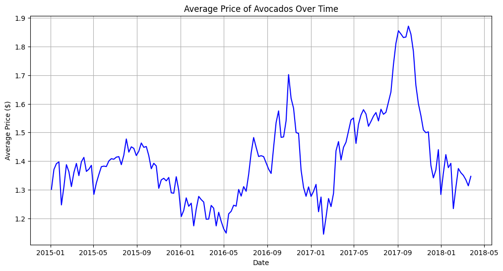

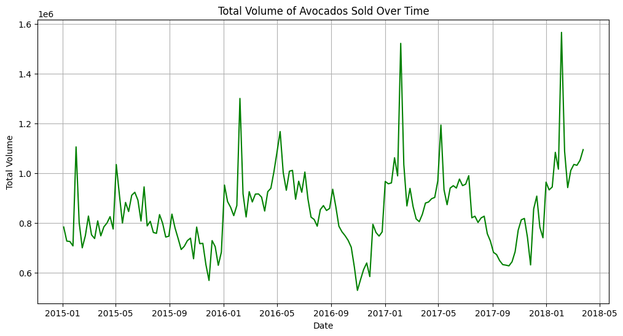

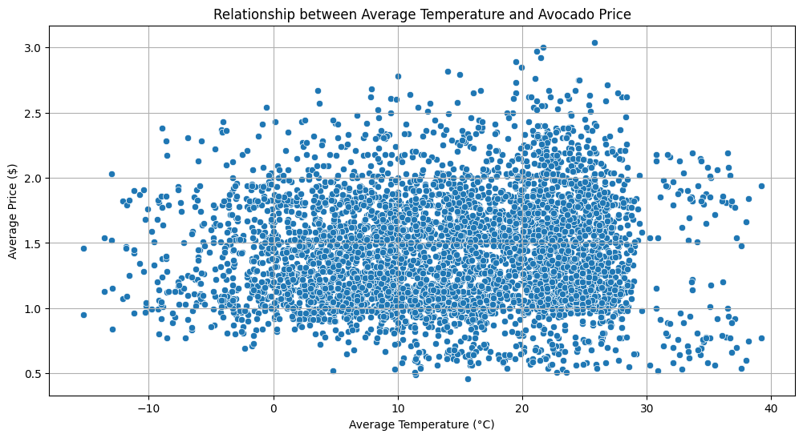

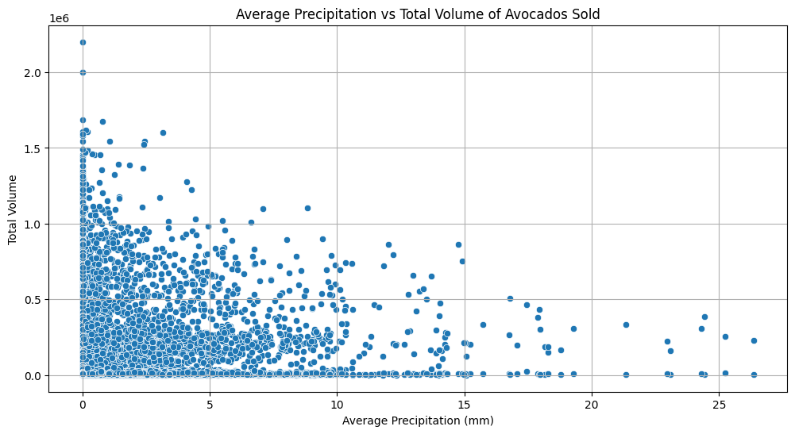

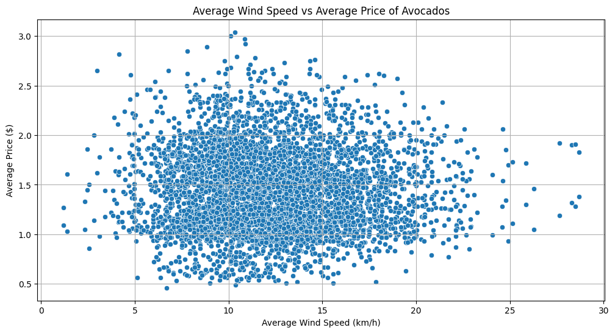

|  | AveragePrice | Total Volume | 4046 | 4225 | 4770 | Total Bags | Small Bags | Large Bags | XLarge Bags | year | avg_temp_c | min_temp_c | max_temp_c | precipitation_mm | snow_depth_mm | avg_wind_dir_deg | avg_wind_speed_kmh | peak_wind_gust_kmh | avg_sea_level_pres_hpa | sunshine_total_min |
| --- | --- | --- | --- | --- | --- | --- | --- | --- | --- | --- | --- | --- | --- | --- | --- | --- | --- | --- | --- | --- |
| count | 18249.000000 | 1.824900e+04 | 1.824900e+04 | 1.824900e+04 | 1.824900e+04 | 1.824900e+04 | 1.824900e+04 | 1.824900e+04 | 18249.000000 | 18249.000000 | 4732.000000 | 5070.000000 | 5070.000000 | 5070.000000 | 3770.000000 | 4054.000000 | 4732.000000 | 0.0 | 4726.000000 | 30.0 |
| mean | 1.405978 | 8.506440e+05 | 2.930084e+05 | 2.951546e+05 | 2.283974e+04 | 2.396392e+05 | 1.821947e+05 | 5.433809e+04 | 3106.426507 | 2016.147899 | 14.158897 | 8.334117 | 19.759199 | 2.473980 | 6.982485 | 200.638357 | 12.295625 | NaN | 1017.616131 | 0.0 |
| std | 0.402677 | 3.453545e+06 | 1.264989e+06 | 1.204120e+06 | 1.074641e+05 | 9.862424e+05 | 7.461785e+05 | 2.439660e+05 | 17692.894652 | 0.939938 | 9.754590 | 9.493175 | 10.371779 | 3.245076 | 31.333548 | 66.248860 | 3.851427 | NaN | 5.106347 | 0.0 |
| min | 0.440000 | 8.456000e+01 | 0.000000e+00 | 0.000000e+00 | 0.000000e+00 | 0.000000e+00 | 0.000000e+00 | 0.000000e+00 | 0.000000 | 2015.000000 | -15.271429 | -20.114286 | -8.985714 | 0.000000 | 0.000000 | 0.000000 | 1.185714 | NaN | 1001.333333 | 0.0 |
| 25% | 1.100000 | 1.083858e+04 | 8.540700e+02 | 3.008780e+03 | 0.000000e+00 | 5.088640e+03 | 2.849420e+03 | 1.274700e+02 | 0.000000 | 2015.000000 | 6.885714 | 1.232143 | 12.142857 | 0.185714 | 0.000000 | 161.666667 | 9.514286 | NaN | 1014.150000 | 0.0 |
| 50% | 1.370000 | 1.073768e+05 | 8.645300e+03 | 2.906102e+04 | 1.849900e+02 | 3.974383e+04 | 2.636282e+04 | 2.647710e+03 | 0.000000 | 2016.000000 | 14.807143 | 8.578571 | 20.628571 | 1.300000 | 0.000000 | 204.400000 | 11.942857 | NaN | 1017.400000 | 0.0 |
| 75% | 1.660000 | 4.329623e+05 | 1.110202e+05 | 1.502069e+05 | 6.243420e+03 | 1.107834e+05 | 8.333767e+04 | 2.202925e+04 | 132.500000 | 2017.000000 | 22.242857 | 16.028571 | 28.257143 | 3.485714 | 0.000000 | 246.500000 | 14.657143 | NaN | 1020.971429 | 0.0 |
| max | 3.250000 | 6.250565e+07 | 2.274362e+07 | 2.047057e+07 | 2.546439e+06 | 1.937313e+07 | 1.338459e+07 | 5.719097e+06 | 551693.650000 | 2018.000000 | 39.200000 | 31.757143 | 46.585714 | 26.357143 | 371.428571 | 349.000000 | 28.685714 | NaN | 1040.260000 | 0.0 |

```python
# Performing the EDA on the merged dataset

# Data Consistency Check and Handling Missing Data
# Checking for missing values in the merged dataset here..
missing_values_merged = merged_dataset.isnull().sum()

# Performing EDA: Generating summary statistics and graphs
# 1. Summary statistics for key variables.
summary_statistics = merged_dataset.describe()

# 2. Graphs
import matplotlib.pyplot as plt
import seaborn as sns

# Graph 1: Average Price of Avocados over Time
plt.figure(figsize=(12, 6))
plt.plot(merged_dataset.groupby('Date')['AveragePrice'].mean(), color='b')
plt.title('Average Price of Avocados Over Time')
plt.xlabel('Date')
plt.ylabel('Average Price ($)')
plt.grid(True)
plt.show()

# Graph 2: Total Volume of Avocados Sold over Time.
plt.figure(figsize=(12, 6))
plt.plot(merged_dataset.groupby('Date')['Total Volume'].mean(), color='g')
plt.title('Total Volume of Avocados Sold Over Time')
plt.xlabel('Date')
plt.ylabel('Total Volume')
plt.grid(True)
plt.show()

# Graph 3: Relationship between Average Temperature and Average Price.
plt.figure(figsize=(12, 6))
sns.scatterplot(x='avg_temp_c', y='AveragePrice', data=merged_dataset)
plt.title('Relationship between Average Temperature and Avocado Price')
plt.xlabel('Average Temperature (°C)')
plt.ylabel('Average Price ($)')
plt.grid(True)
plt.show()

# Graph 4: Average Precipitation vs Total Volume Sold
plt.figure(figsize=(12, 6))
sns.scatterplot(x='precipitation_mm', y='Total Volume', data=merged_dataset)
plt.title('Average Precipitation vs Total Volume of Avocados Sold')
plt.xlabel('Average Precipitation (mm)')
plt.ylabel('Total Volume')
plt.grid(True)
plt.show()

# Graph 5: Average Wind Speed vs Average Price.
plt.figure(figsize=(12, 6))
sns.scatterplot(x='avg_wind_speed_kmh', y='AveragePrice', data=merged_dataset)
plt.title('Average Wind Speed vs Average Price of Avocados')
plt.xlabel('Average Wind Speed (km/h)')
plt.ylabel('Average Price ($)')
plt.grid(True)
plt.show()

summary_statistics
```

Exploratory Data Analysis (EDA) Summary of the Merged Dataset

Summary Statistics Overview:

- The dataset contains a wide range of values for avocado sales (Total Volume) and prices (AveragePrice), as well as various weather metrics like average temperature (avg_temp_c), precipitation (precipitation_mm), and wind speed (avg_wind_speed_kmh).

Graphical Insights:

1. Average Price of Avocados Over Time:

The graph shows fluctuations in the average price of avocados over the observed period. This could indicate seasonality or other market dynamics affecting avocado prices.

1. Total Volume of Avocados Sold Over Time:

This graph depicts the trends in avocado sales volumes, highlighting peaks and troughs that may correspond to different seasons or market changes.

1. Relationship Between Average Temperature and Avocado Price:

The scatterplot explores any apparent correlation between average temperature and avocado prices. A pattern or lack thereof could suggest the influence of weather on price dynamics.

1. Average Precipitation vs. Total Volume of Avocados Sold:

This graph examines the relationship between precipitation levels and avocado sales volumes, which could reveal how weather conditions impact avocado supply and demand.

1. Average Wind Speed vs. Average Price of Avocados:

The scatterplot investigates if there's any correlation between wind speed and avocado prices, potentially indicating the effect of weather conditions on avocado pricing.

Missing Values:

- There are missing values in several weather-related columns. These gaps need to be addressed for a more accurate analysis.

Next Steps for Model Building Ideas:

1. Price Prediction Model: Utilize variables like date, region, and weather conditions to predict future avocado prices.
2. Sales Volume Correlation Analysis: Examine the impact of weather conditions on avocado sales volumes, potentially building a model to predict sales trends based on weather data.

Based on the data I have analyzed so far, my thoughts regarding two models I could build are as follows:

Price Prediction Model: This model aims to predict the average price of avocados based on factors such as region, date, and various weather conditions.

Sales Volume Correlation Analysis: This analysis will explore the relationship between weather conditions and avocado sales volumes, potentially leading to a model that can predict sales trends based on weather data.

For both of these analyses, I'll need to prepare the data appropriately, select relevant features, and choose suitable modeling techniques.

1. Price Prediction Model Steps:
- Feature Selection: I will choose relevant features such as date, region, and weather conditions (temperature, precipitation, etc.).
- Data Preprocessing: I will handle missing values, encode categorical variables, and normalize or standardize the data.
- Model Selection: I will choose a regression model suitable for time series and continuous data, like linear regression, random forest, or gradient boosting.
- Model Training and Evaluation: I'll train the model on a training dataset and evaluate its performance on a test dataset using metrics like RMSE (Root Mean Square Error).
1. Sales Volume Correlation Analysis Steps:
- Exploratory Analysis: Initially, I would explore correlations between sales volumes and weather conditions using statistical methods.
- Feature Selection: Based on the exploratory analysis, select features that show potential influence on sales volumes.
- Model Building: Depending on the nature of the correlation, I will choose a suitable predictive model, such as linear regression for continuous relationships or decision trees for non-linear patterns.
- Model Evaluation: I will assess the model's accuracy and reliability in predicting sales volumes.

```python
%%shell
jupyter nbconvert --to html '/content/drive/MyDrive/Colab Notebooks/FinalTutorial.ipynb'
```

```
[NbConvertApp] Converting notebook /content/drive/MyDrive/Colab Notebooks/FinalTutorial.ipynb to html
[NbConvertApp] Writing 1781332 bytes to /content/drive/MyDrive/Colab Notebooks/FinalTutorial.html
```